## Loading and preprocessing the data

```r
activity <- read.csv("activity.csv",header=TRUE)
```

Converting the interval to a time format (POSIXlt) and adding the column to the dataset

```r
hour <- trunc(activity$interval/100)
minute <- activity$interval - hour*100
hour <- strptime(hour,"%H")
minute <- strptime(minute,"%M")
time <- paste(as.character(format(hour, "%H")),as.character(format(minute, "%M")),sep=":")
time <- strptime(time,format="%H:%M")
activity <- cbind(activity,time)
str(activity)
```

```
## 'data.frame':    17568 obs. of  4 variables:
##  $ steps   : int  NA NA NA NA NA NA NA NA NA NA ...
##  $ date    : Factor w/ 61 levels "2012-10-01","2012-10-02",..: 1 1 1 1 1 1 1 1 1 1 ...
##  $ interval: int  0 5 10 15 20 25 30 35 40 45 ...
##  $ time    : POSIXct, format: "2015-05-16 00:00:00" "2015-05-16 00:05:00" ...
```

## Q1. What is mean total number of steps taken per day?

1. Calculating the total number of steps taken in a day by aggregating all the steps in the day. Days with NAs input are ignored

```r
activity$date <- as.Date(activity$date)
totsteps <- aggregate(steps~date, data=activity, sum)
```

2. Creating the histogram - Plotting the frequency of the total number of steps taken each day

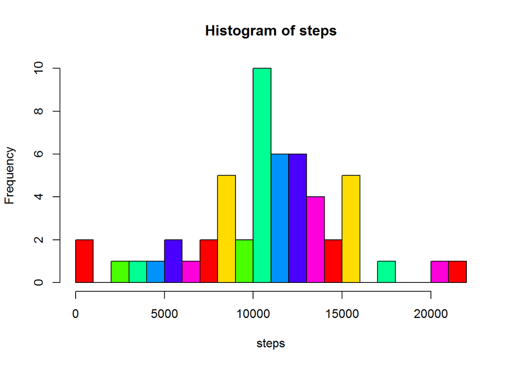

```r
x <- seq(0,22000,1000)
with(totsteps, hist(steps,breaks = x, col=rainbow(7)))
```

3. Calculate the mean and median of the total steps taken per day The mean and median refers to the results derived in Q1a above

```r
Meansteps   <- mean(totsteps$steps)
Mediansteps <- median(totsteps$steps)
```

#### Mean = 1.0766 × 10<sup>4</sup>, Median = 10765

## Q2. What is the average daily activity pattern?

1. Make a time series plot (i.e. type = “l”) of the 5-minute interval (x-axis) and the average number of steps taken, averaged across all days (y-axis)

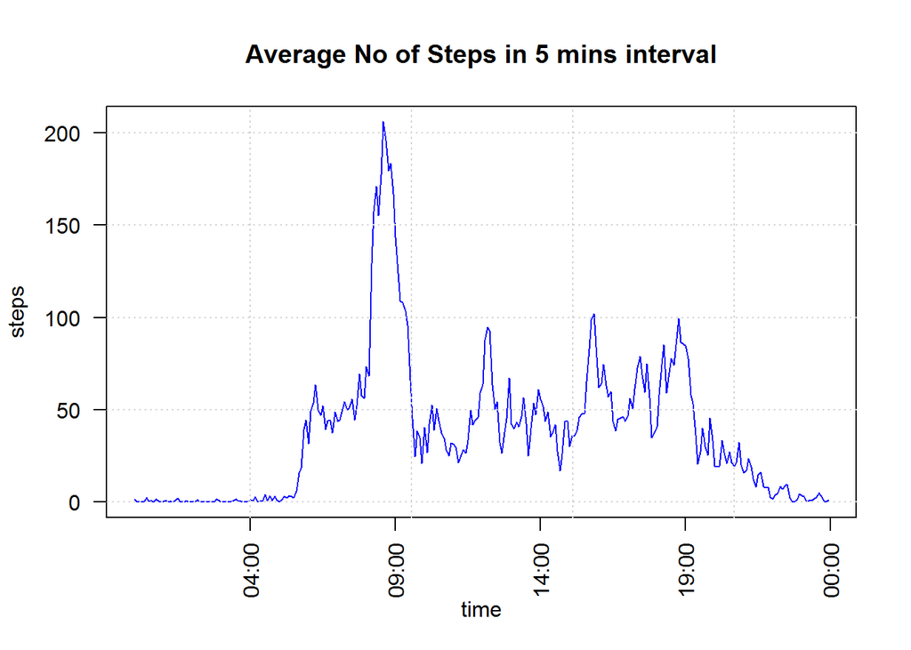

```r
dailypattern <- aggregate(steps~time, data=activity, mean)
with(dailypattern, plot(steps~time,type = "l",col="blue",las=2))
grid()
title(main="Average No of Steps in 5 mins interval")
```

2. Which 5-minute interval, on average across all the days in the dataset, contains the maximum number of steps?

```r
order(dailypattern[,2])
```

[output not shown]

```r
answer <- dailypattern[order(dailypattern[,2])[288],]  ## The last item has the highest number
answer
```

```
##                    time steps
## 104 2015-05-16 08:35:00 206.2
```

#### The highest average number in a 5-min interval is 206.1698

#### and the time is 08:35

## Q3. Imputing missing values

1. Calculate and report the total number of missing values in the dataset (i.e. the total number of rows with NAs)

```r
NAs <- is.na(activity$steps)
sum_NAs <- sum(NAs)
```

#### The total number of rows with NAs is 2304

2. Devise a strategy for filling in all of the missing values in the dataset.
- The strategy will be to replace the missing values with the mean of that interval from the mean values calculated for each intervals in Q2 above.

```r
names(dailypattern) <- c("time","mean")
activity1 <- merge(activity,dailypattern,by.x="time",by.y="time")
for (x in 1:length(activity1$steps)){
    if (is.na(activity1$steps[x])){activity1$steps[x] <- activity1$mean[x]}
    }
```

3. Create a new dataset that is equal to the original dataset but with the missing data filled in. The structure of the new and old dataset is shown

```r
str(activity1)
```

```
## 'data.frame':    17568 obs. of  5 variables:
##  $ time    : POSIXct, format: "2015-05-16 00:00:00" "2015-05-16 00:00:00" ...
##  $ steps   : num  1.72 0 0 0 0 ...
##  $ date    : Date, format: "2012-10-01" "2012-11-23" ...
##  $ interval: int  0 0 0 0 0 0 0 0 0 0 ...
##  $ mean    : num  1.72 1.72 1.72 1.72 1.72 ...
```

```r
str(activity)
```

```
## 'data.frame':    17568 obs. of  4 variables:
##  $ steps   : int  NA NA NA NA NA NA NA NA NA NA ...
##  $ date    : Date, format: "2012-10-01" "2012-10-01" ...
##  $ interval: int  0 5 10 15 20 25 30 35 40 45 ...
##  $ time    : POSIXct, format: "2015-05-16 00:00:00" "2015-05-16 00:05:00" ...
```

4. Make a histogram of the total number of steps taken each day and Calculate and report the mean and median total number of steps taken per day. Do these values differ from the estimates from the first part of the assignment? What is the impact of imputing missing data on the estimates of the total daily number of steps?

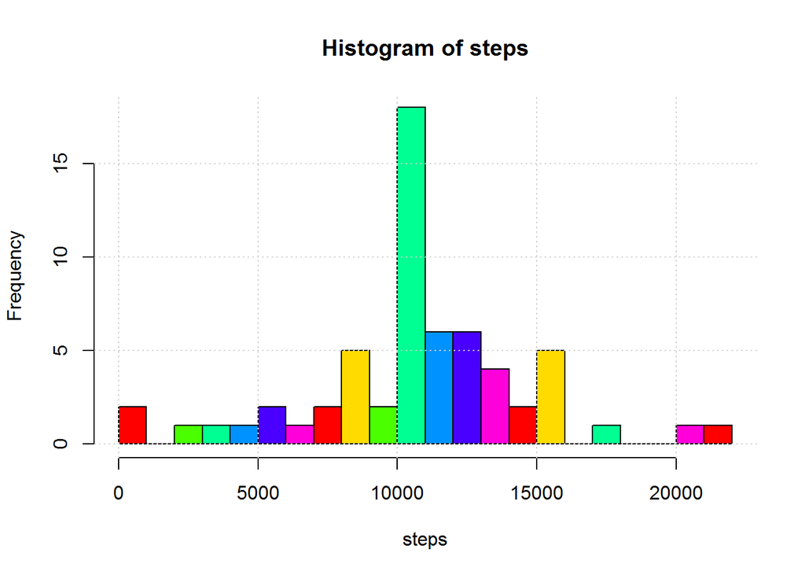

```r
totsteps1 <- aggregate(steps~date, data=activity1, sum)
x <- seq(0,22000,1000)
with(totsteps1, hist(steps,breaks = x, col=rainbow(7)))
grid()
```

```r
Meansteps1   <- mean(totsteps1$steps)
Mediansteps1 <- median(totsteps1$steps)
```

#### Before imputation : Mean = 1.0766 × 10<sup>4</sup> Median = 10765

#### After imputation : Mean = 1.0766 × 10<sup>4</sup> Median = 1.0766 × 10<sup>4</sup>

#### There are thus no change in the mean and slight variation in the median before and after the imputation

## Q4. Are there differences in activity patterns between weekdays and weekends?

1. Create a new factor variable in the dataset with two levels - “weekday” and “weekend” indicating whether a given date is a weekday or weekend day.

```r
activity1$date <- as.Date(activity1$date)
daysofweek <- weekdays(activity1$date)
days <- daysofweek
## Check for weekdays or weekends
for (x in 1:length(daysofweek)){
    if (daysofweek[x] == "Saturday" | daysofweek[x] == "Sunday")
    {days[x] <- "Weekend"}
    else
    {days[x] <- "Weekday"}
}
activity1 <- cbind(activity1,days,daysofweek)
```

2. Make a panel plot containing a time series plot (i.e. type = “l”) of the 5-minute interval (x-axis) and the average number of steps taken, averaged across all weekday days or weekend days (y-axis).

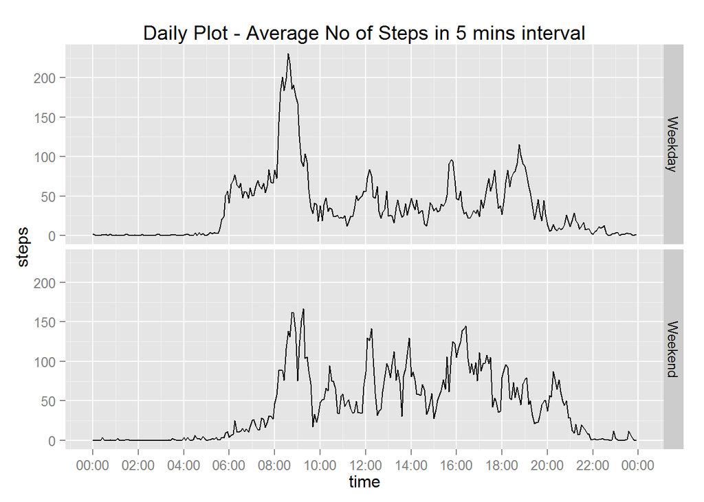

```r
library(ggplot2)
library(scales)
dailypattern1 <- aggregate(steps~time+days, data=activity1, mean)
ggplot(dailypattern1, aes(x= time, y=steps)) +
    geom_line() +
    facet_grid(days~.) +
    scale_x_datetime(labels = date_format("%H:%M"),breaks = date_breaks("2 hour")) +
    labs(title="Daily Plot - Average No of Steps in 5 mins interval")
```